# Security of Big Data Analitics

### Laboratory 05 "Attacks on linear regression"

#### Please insert bellow your firstname, lastnema and ID number and run this cell

##### (if cell is not active, clik twice on it)

Mateusz Wiśniewski - 148327

Linear regression is one of the simplest supervised learning algorithms in machine learning. I am sure that if you have studied technical subjects, you have certainly encountered it. It is one of the simplest algorithms commonly used for forecasting and in many places it gives sufficient results. Its biggest advantage is its simple design, which ensures full interpretability of the model.

In this exercise, you will learn about potential attacks on linear regression.

To complete this exercise, use the code and datasets used in exercise 04.

```python
%matplotlib inline
# is a command used in the Jupyter Notebook or JupyterLab interactive environment that
#imports the NumPy and Matplotlib libraries and sets up the display of graphs directly below the code.

# import from the module linear_model LinearRegression class
# This way we don't have to implement the formulas by ourselves
from sklearn.linear_model import LinearRegression

#import from the module metrics mean_squared_error class
from sklearn.metrics import mean_squared_error
import numpy as np
import matplotlib.pyplot as plt

import pandas as pd
from sklearn.preprocessing import LabelEncoder
from sklearn.model_selection import train_test_split

filename = "insurance.csv"

data = pd.read_csv(filename)
data.head()

label_encoder = LabelEncoder()
data['sex'] = label_encoder.fit_transform(data['sex'])
data['smoker'] = label_encoder.fit_transform(data['smoker'])

def test_field(field_name):
    X = data[field_name].values.reshape(-1, 1)
    y = data['charges']

    X_train, X_test, y_train, y_test = train_test_split(X, y, test_size=0.2, random_state=42)

    model = LinearRegression()
    model.fit(X_train, y_train)

    y_pred = model.predict(X_test)
    mse = mean_squared_error(y_test, y_pred)

    print(f'MSE: {mse}')

    # Plot
    plt.figure(figsize=(10, 5), dpi=110)
    plt.scatter(X_test, y_test, color='green')
    plt.plot(X_test, model.predict(X_test), color='red')
    plt.xlabel(field_name)
    plt.ylabel('Charges')
    plt.show()

def test_x_and_y(x, y):
    X_train, X_test, y_train, y_test = train_test_split(x.values.reshape(-1, 1), y, test_size=0.2, random_state=42)

    model_a1 = LinearRegression()
    model_a1.fit(X_train, y_train)

    y_pred_a1 = model_a1.predict(X_test)
    mse_a1 = mean_squared_error(y_test, y_pred_a1)

    print(f'MSE with disturbing values: {mse_a1}')

    # Plot
    plt.figure(figsize=(10, 5), dpi=110)
    plt.scatter(X_test, y_test, color='green')
    plt.plot(X_test, model_a1.predict(X_test), color='red')
    plt.xlabel('BMI with disturbance')
    plt.ylabel('Charges with disturbance')
    plt.show()
```

# Exercise 1

#### Poissoning attack - adding disturbance values.

In this case add disturbing values to the data prepared at the beginning of the exercise

1. Add disturbing values to the x and y values (store the new values in new variables, e.g. x_a1, y_a1)

As a source of disturbing values, use a generator of numbers with a normal distribution with expectation value = 0, standard deviation equal to 0.1 and number of samples equal to the number of samples x: x_dv1 = np.random.normal(0, 0.1, 100)

If you want add disturbing values to oryginal x you can use commend: x = x + x_dv1

2. Train the new model on the modified values and compare its accuracy with the initial data
3. Add perturbations to y only or x only, train models and compare results
4. Is it possible to modify the data in such a way that it does not affect the result of the regression algorithm?
5. How can this type of attack be detected?
6. Can it be counteracted?

```
Original
MSE: 149085057.03839505
```

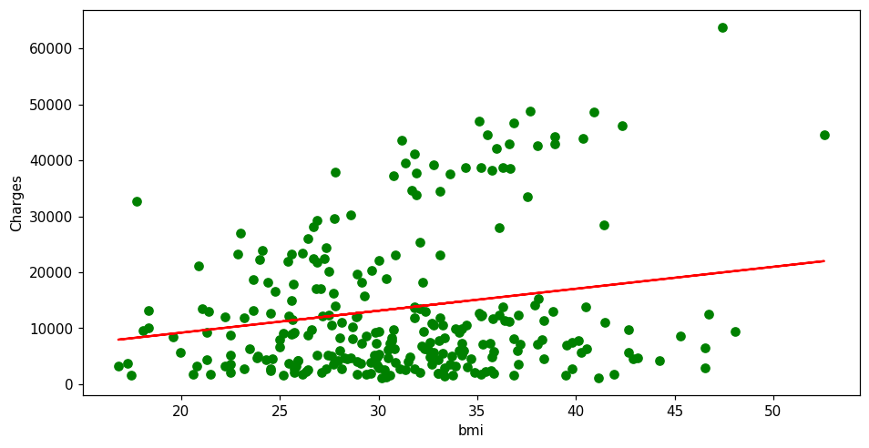

```
Add disturbing values to the x and y values
MSE with disturbing values: 153696181.91076034
```

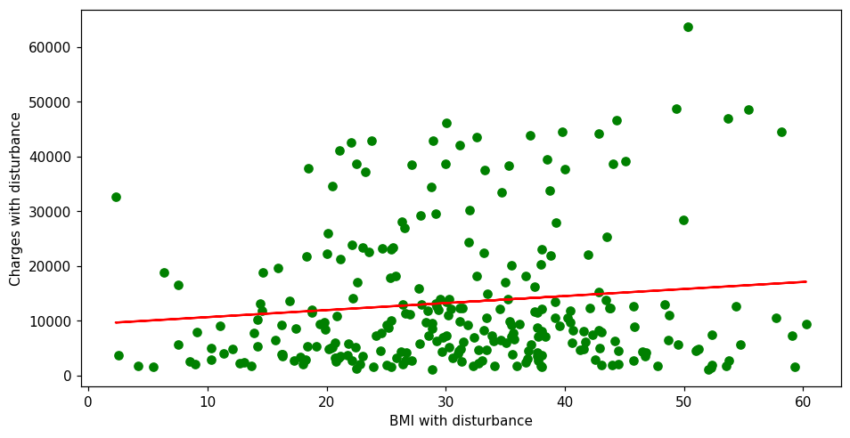

```
Add disturbing values to the x values
MSE with disturbing values: 153605501.05391574
```

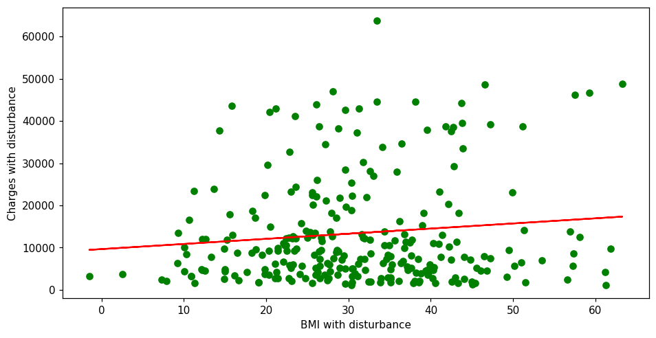

```
Add disturbing values to the y values
MSE with disturbing values: 149049647.9140167
```

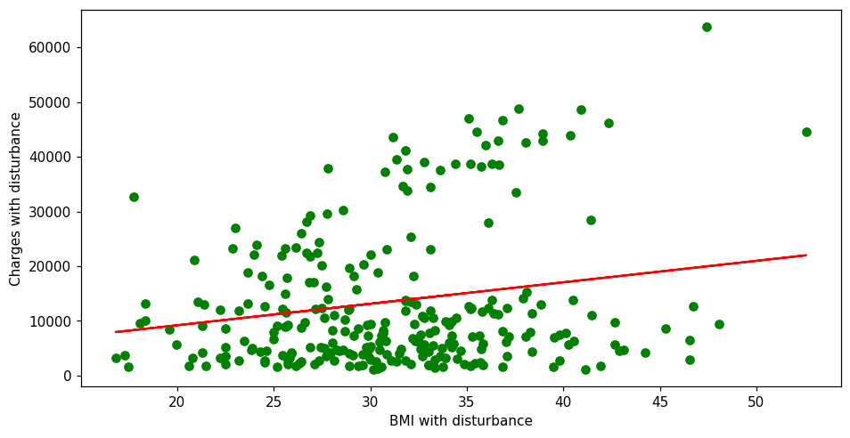

```python
#code

NOISE = 10

# Original
print('Original')
test_field('bmi')

# Add disturbing values to the x and y values
print('Add disturbing values to the x and y values')
x_dv1 = np.random.normal(0, NOISE, len(data['bmi']))
y_dv1 = np.random.normal(0, NOISE, len(data['charges']))

x_a1 = data['bmi'] + x_dv1
y_a1 = data['charges'] + y_dv1

test_x_and_y(x_a1, y_a1)

# Add disturbing values to the x values
print('Add disturbing values to the x values')
x_dv2 = np.random.normal(0, NOISE, len(data['bmi']))

x_a2 = data['bmi'] + x_dv2

test_x_and_y(x_a2, data['charges'])

# Add disturbing values to the y values
print('Add disturbing values to the y values')
y_dv3 = np.random.normal(0, NOISE, len(data['charges']))

y_a3 = data['charges'] + y_dv3

test_x_and_y(data['bmi'], y_a3)
```

your conclusions (if not active click twice):

#### 4. Is it possible to modify the data in such a way that it does not affect the result of the regression algorithm?

Yes, it is possible. This can be achieved by adding noise that is small enough to not alter the trend in the data.

#### 5. How can this type of attack be detected?

This type of attack can be detected by:

- Analysis of outliers
- Continuous monitoring of performance of model where sudden spikes can indicate an attack

#### 6. Can it be counteracted?

Yes, by mainly:

- Removing outliers and anomalies from data before training
- Regulating model so it doesn't overfit to outliers
- Using a confirmed, safe dataset for training
- Analyzing model's performance with a confirmed, safe test dataset.

# Exercise 2

#### Poissoning attack - deletion of random data

In this case, we will check how the model performance is affected by deleting selected data used for traning

Let us assume, that 10 percent samples will be deleted. Please, propose solusion for removing 10% samples.

if you want remove random element ypu can use following code:

random_index = np.random.randint(len(my_list))

removed_element = np.delete(my_list, random_index)

Remember, you shold remove "random_element" in both tables: x and y

After removing the samples, train a new model and compare its accuracy with the original model.

1. Is it possible to modify the data in such a way that it does not affect the result of the regression algorithm?
2. How can this type of attack be detected?
3. Can it be counteracted?

```
Original
MSE: 135983957.4805469
```

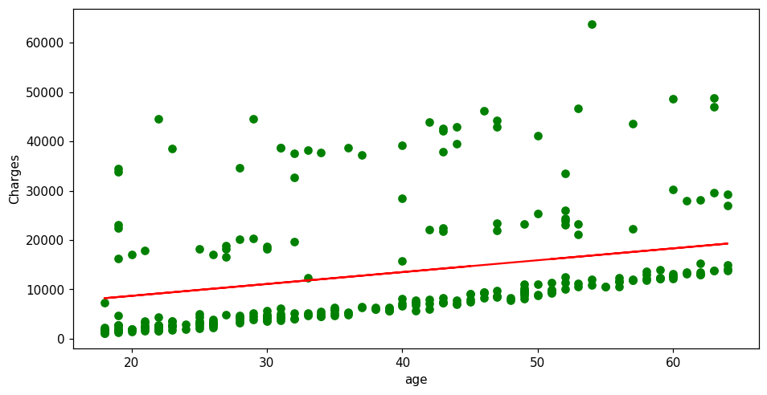

```
Remove 10.0% of the data
MSE with disturbing values: 155621907.9530492
```

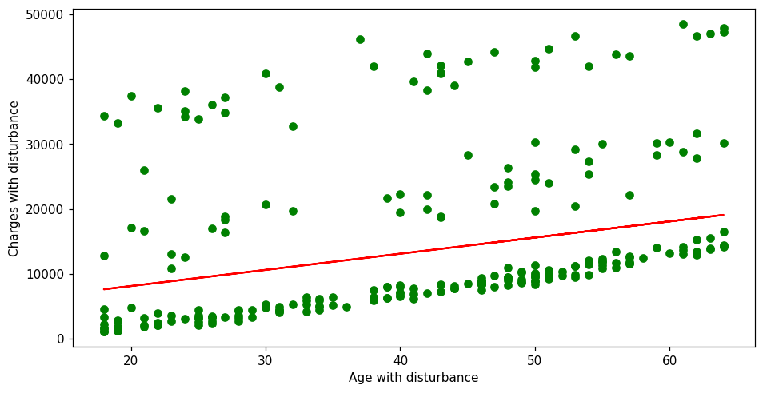

```
Remove 20.0% of the data
MSE with disturbing values: 141949826.06050676
```

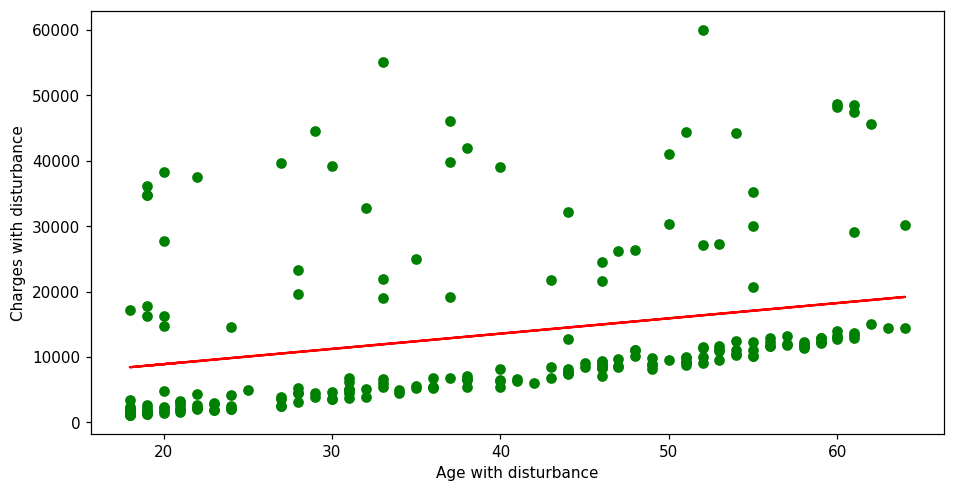

```
Remove 30.0% of the data
MSE with disturbing values: 123838218.48980236
```

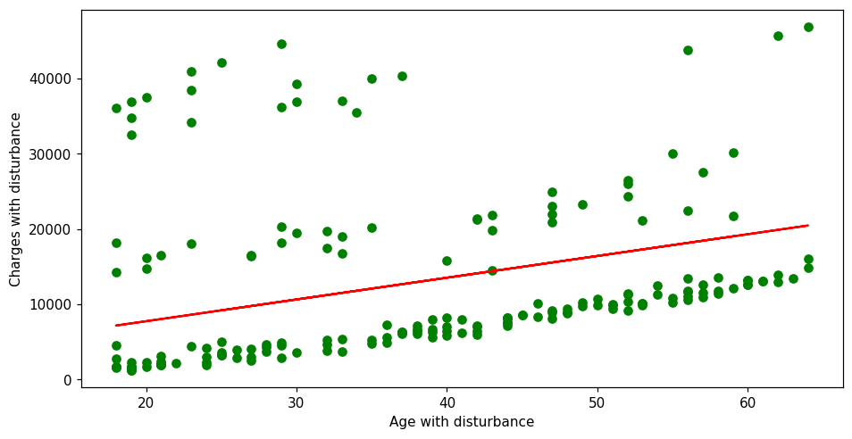

```python
#code

def new_x_and_y(to_remove):
    num_samples = len(data['age'])
    num_remove = int(to_remove * num_samples)

    # Randomly select indices to remove
    remove_indices = np.random.choice(num_samples, num_remove, replace=False)

    # Remove the selected indices from x and y
    x_new = np.delete(data['age'].values, remove_indices)
    y_new = np.delete(data['charges'].values, remove_indices)

    x_new = x_new.reshape(-1, 1)
    y_new = y_new.reshape(-1, 1)

    return x_new, y_new

def test_x_and_y(x, y):
    X_train, X_test, y_train, y_test = train_test_split(x, y, test_size=0.2, random_state=42)

    model_a1 = LinearRegression()
    model_a1.fit(X_train, y_train)

    y_pred_a1 = model_a1.predict(X_test)
    mse_a1 = mean_squared_error(y_test, y_pred_a1)

    print(f'MSE with disturbing values: {mse_a1}')

    # Plot
    plt.figure(figsize=(10, 5), dpi=110)
    plt.scatter(X_test, y_test, color='green')
    plt.plot(X_test, model_a1.predict(X_test), color='red')
    plt.xlabel('Age with disturbance')
    plt.ylabel('Charges with disturbance')
    plt.show()


# Original
print('Original')
test_field('age')

REMOVE = 0.1
print(f"Remove {REMOVE * 100}% of the data")
x_r1, y_r1 = new_x_and_y(REMOVE)
test_x_and_y(x_r1, y_r1)

REMOVE = 0.2
print(f"Remove {REMOVE * 100}% of the data")
x_r2, y_r2 = new_x_and_y(REMOVE)
test_x_and_y(x_r2, y_r2)

REMOVE = 0.3
print(f"Remove {REMOVE * 100}% of the data")
x_r3, y_r3 = new_x_and_y(REMOVE)
test_x_and_y(x_r3, y_r3)
```

your conclusions (if not active click twice):

1. Yes, this can be achieved by making sure not enough of data is removed and deleted samples are not statistically significant.
2. This type of attack can be detected by:
   - Analyzing the distribution of data
   - Monitoring the performance of the model for sudden changes.
3. Yes, it can be counteracted by:
   - Cleaning the data to remove outliers and anomalies.
   - Implementing robust regression techniques that are less sensitive to data modifications.

# Exercise 3

#### Poissoning attack - rescaling of the training data

In this case, we will look at how the scaling of the data used for traning affects the performance of the model.

Multiply the original data by a selected number in the range (1;6) or choose own range. Use the scaled data to train another model. Verify its accuracy against the original data.

1. Is it possible to modify the data in such a way that it does not affect the result of the regression algorithm?
2. How can this type of attack be detected?
3. Can it be counteracted?

```
Original
MSE: 149085057.03839505
```

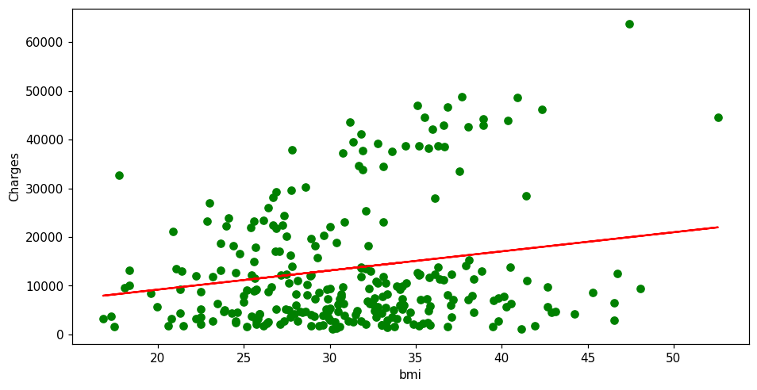

```
Scale x by 2
MSE with disturbing values: 149085057.03839505
```

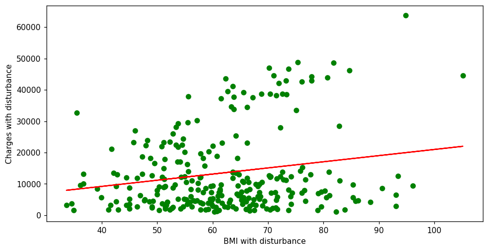

```
Scale x by 3
MSE with disturbing values: 149085057.03839505
```

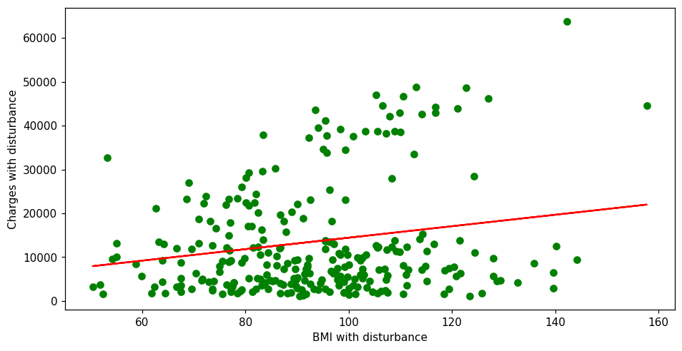

```
Scale x by 4
MSE with disturbing values: 149085057.03839505
```

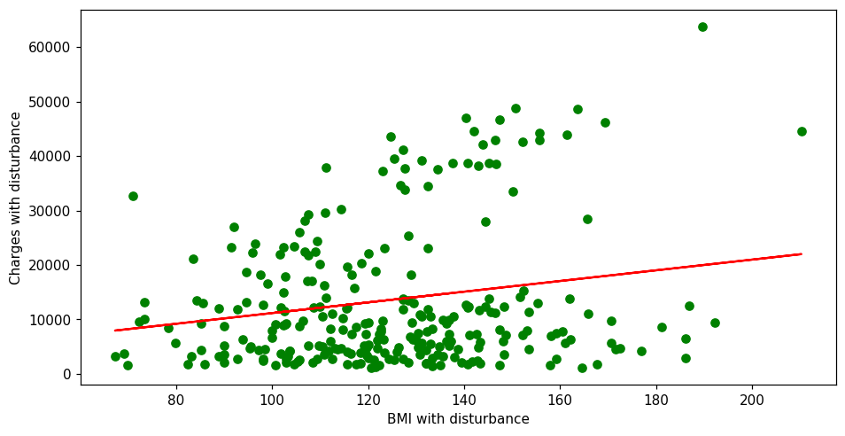

```
Scale x by 5
MSE with disturbing values: 149085057.03839505
```

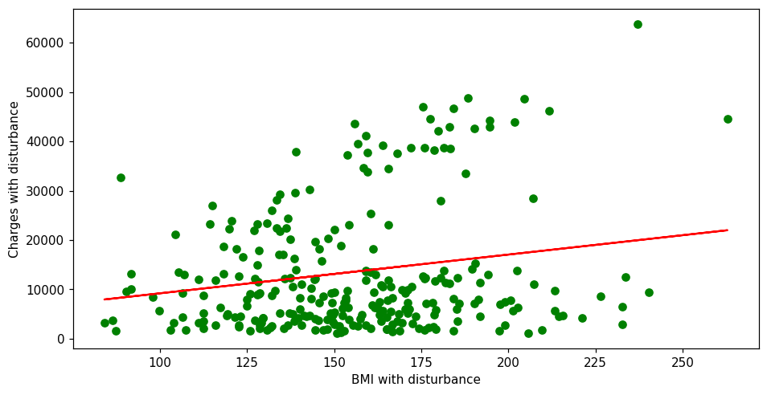

```
Scale x by 6
MSE with disturbing values: 149085057.03839505
```

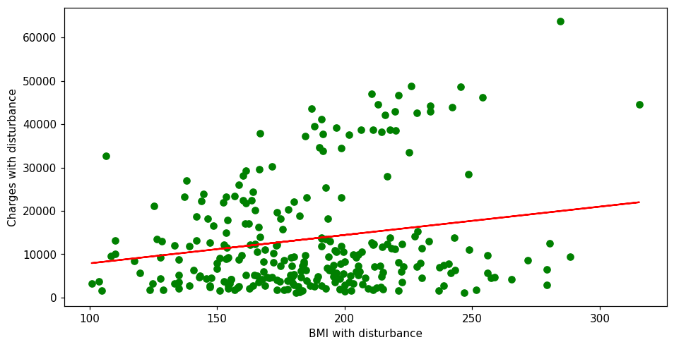

```
Scale x by 7
MSE with disturbing values: 149085057.03839505
```

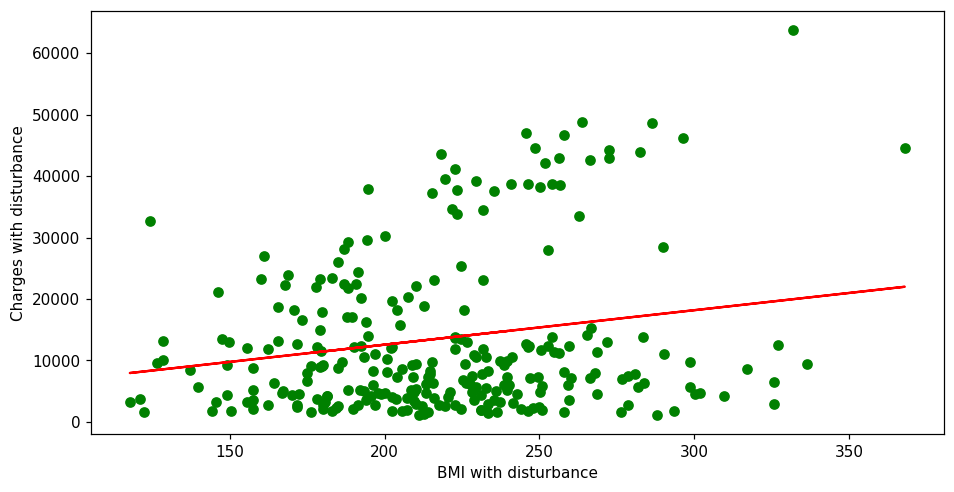

```
Scale x by 8
MSE with disturbing values: 149085057.03839505
```

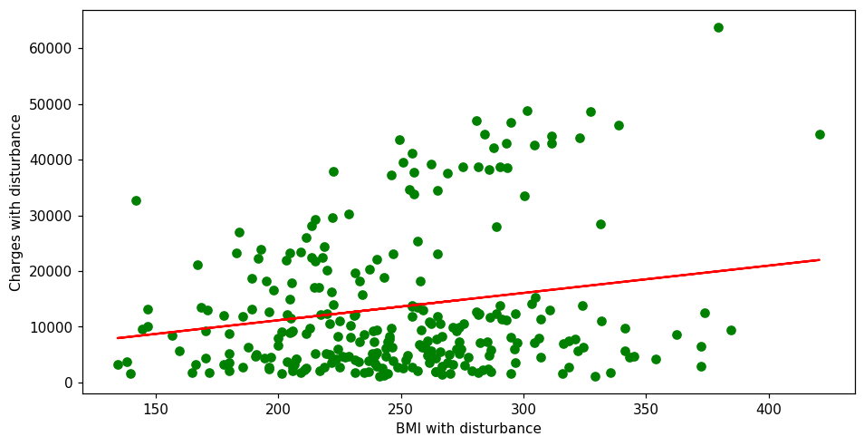

```
Scale x by 9
MSE with disturbing values: 149085057.03839505
```

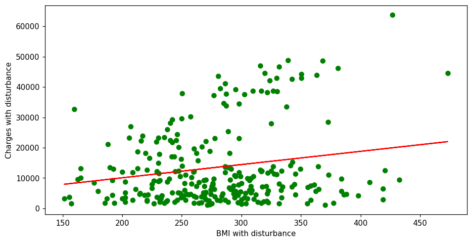

```
Scale y by 2
MSE with disturbing values: 596340228.1535802
```

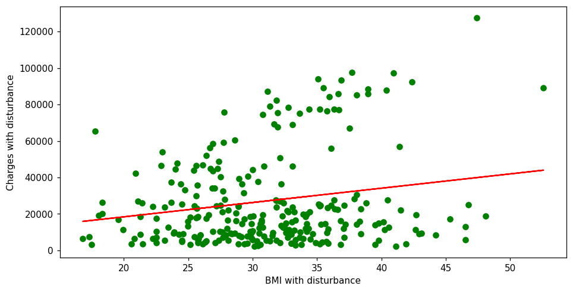

```
Scale y by 3
MSE with disturbing values: 1341765513.3455555
```

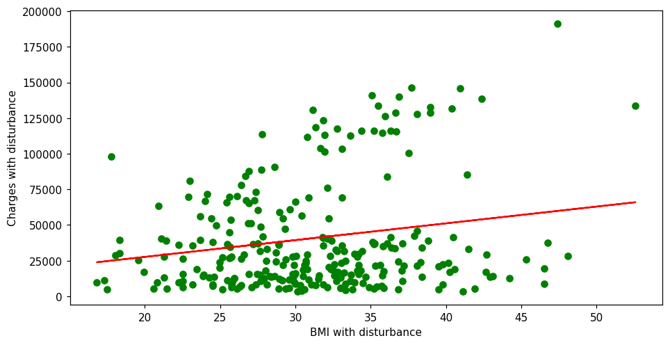

```
Scale y by 4
MSE with disturbing values: 2385360912.6143208
```

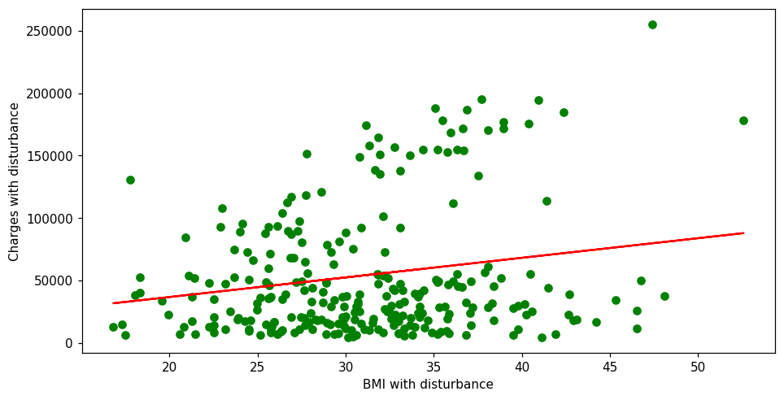

```
Scale y by 5
MSE with disturbing values: 3727126425.9598765
```

[5 more figures not shown]

```python
#code

def scale_x(scale):
    x_new = data['bmi'].map(lambda x: x * scale)
    x_new = x_new.values.reshape(-1, 1)
    return x_new

def scale_y(scale):
    y_new = data['charges'].map(lambda y: y * scale)
    y_new = y_new.values.reshape(-1, 1)
    return y_new

def test_x_and_y(x, y):
    X_train, X_test, y_train, y_test = train_test_split(x, y, test_size=0.2, random_state=42)

    model_a1 = LinearRegression()
    model_a1.fit(X_train, y_train)

    y_pred_a1 = model_a1.predict(X_test)
    mse_a1 = mean_squared_error(y_test, y_pred_a1)

    print(f'MSE with disturbing values: {mse_a1}')

    # Plot
    plt.figure(figsize=(10, 5), dpi=110)
    plt.scatter(X_test, y_test, color='green')
    plt.plot(X_test, model_a1.predict(X_test), color='red')
    plt.xlabel('BMI with disturbance')
    plt.ylabel('Charges with disturbance')
    plt.show()

def test_for_scales():
    for i in range(2, 10):
        scale = i
        print(f"Scale x by {scale}")
        x_new = scale_x(scale)
        test_x_and_y(x_new, data['charges'])

    for i in range(2, 10):
        scale = i
        print(f"Scale y by {scale}")
        y_new = scale_y(scale)
        test_x_and_y(data['bmi'].values.reshape(-1, 1), y_new)


# Original
print('Original')
test_field('bmi')

test_for_scales()
```

your conclusions (if not active click twice):

1. Yes,this can be achieved by scaling the data uniformly
2. This can be detected by:
- Monitoring the distribution of data and sanity checking values
3. It can be counteracted by:
- Normalizing or standardizing the data before training

## Answer the questions:

your answers (if not active click twice):